# Credit Card Users Churn Prediction

```python
#confirming the inverse mapping has been succesful on a sample of the test data
X_test.sample(10)
```

|  | Customer_Age | Gender | Dependent_count | Education_Level | Marital_Status | Income_Category | Card_Category | Months_on_book | Total_Relationship_Count | Months_Inactive_12_mon | Contacts_Count_12_mon | Credit_Limit | Total_Revolving_Bal | Total_Amt_Chng_Q4_Q1 | Total_Trans_Amt | Total_Trans_Ct | Total_Ct_Chng_Q4_Q1 | Avg_Utilization_Ratio |
| --- | --- | --- | --- | --- | --- | --- | --- | --- | --- | --- | --- | --- | --- | --- | --- | --- | --- | --- |
| 1876 | 41.0 | M | 2.0 | College | Married | $80K - $120K | Blue | 33.0 | 2.0 | 3.0 | 3.0 | 14682.0 | 2517.0 | 1.041 | 8193.0 | 72.0 | 0.846 | 0.171 |
| 354 | 40.0 | F | 2.0 | Doctorate | Single | $40K - $60K | Blue | 36.0 | 6.0 | 1.0 | 3.0 | 2797.0 | 850.0 | 0.953 | 3652.0 | 64.0 | 1.370 | 0.304 |
| 507 | 51.0 | M | 4.0 | NaN | Married | $80K - $120K | Blue | 47.0 | 4.0 | 3.0 | 2.0 | 3861.0 | 622.0 | 0.794 | 4816.0 | 81.0 | 0.976 | 0.161 |
| 1011 | 49.0 | M | 2.0 | High School | Single | $80K - $120K | Silver | 40.0 | 4.0 | 3.0 | 2.0 | 34516.0 | 1313.0 | 0.583 | 15154.0 | 99.0 | 0.833 | 0.038 |
| 115 | 56.0 | F | 1.0 | NaN | Married | Less than $40K | Blue | 45.0 | 4.0 | 1.0 | 2.0 | 3132.0 | 2230.0 | 0.780 | 4412.0 | 73.0 | 0.659 | 0.712 |
| 1575 | 49.0 | F | 3.0 | College | Married | $40K - $60K | Blue | 44.0 | 6.0 | 2.0 | 3.0 | 2578.0 | 1590.0 | 0.657 | 4683.0 | 89.0 | 0.618 | 0.617 |
| 729 | 39.0 | F | 1.0 | High School | Married | Less than $40K | Blue | 25.0 | 2.0 | 2.0 | 1.0 | 2024.0 | 0.0 | 0.801 | 2870.0 | 36.0 | 0.500 | 0.000 |
| 568 | 44.0 | F | 3.0 | College | Single | Less than $40K | Blue | 40.0 | 2.0 | 1.0 | 3.0 | 3269.0 | 0.0 | 0.797 | 5022.0 | 85.0 | 0.771 | 0.000 |
| 1895 | 46.0 | F | 3.0 | Graduate | Single | Less than $40K | Silver | 39.0 | 4.0 | 3.0 | 2.0 | 12222.0 | 1260.0 | 1.138 | 3418.0 | 78.0 | 0.733 | 0.103 |
| 1140 | 26.0 | M | 0.0 | Uneducated | Single | Less than $40K | Blue | 36.0 | 4.0 | 3.0 | 4.0 | 2665.0 | 1567.0 | 0.586 | 2514.0 | 64.0 | 0.455 | 0.588 |

**4.Encoding categorical variables**

```python
X_train=pd.get_dummies(X_train,drop_first=True)
X_val=pd.get_dummies(X_val,drop_first=True)
X_test=pd.get_dummies(X_test,drop_first=True)
print(X_train.shape, X_val.shape, X_test.shape)
```

```
(7595, 28) (2532, 28) (2026, 28)
```

After the one-hot-encoding the predictors data frames consists of 28 columns instead of 18

```python
X_train.head()
```

|  | Customer_Age | Dependent_count | Months_on_book | Total_Relationship_Count | Months_Inactive_12_mon | Contacts_Count_12_mon | Credit_Limit | Total_Revolving_Bal | Total_Amt_Chng_Q4_Q1 | Total_Trans_Amt | Total_Trans_Ct | Total_Ct_Chng_Q4_Q1 | Avg_Utilization_Ratio | Gender_M | Education_Level_Doctorate | Education_Level_Graduate | Education_Level_High School | Education_Level_Post-Graduate | Education_Level_Uneducated | Marital_Status_Married | Marital_Status_Single | Income_Category_$40K - $60K | Income_Category_$60K - $80K | Income_Category_$80K - $120K | Income_Category_Less than $40K | Card_Category_Gold | Card_Category_Platinum | Card_Category_Silver |
| --- | --- | --- | --- | --- | --- | --- | --- | --- | --- | --- | --- | --- | --- | --- | --- | --- | --- | --- | --- | --- | --- | --- | --- | --- | --- | --- | --- | --- |
| 0 | 46.0 | 4.0 | 42.0 | 4.0 | 0.0 | 3.0 | 13376.0 | 1633.0 | 0.980 | 4515.0 | 63.0 | 1.172 | 0.122 | False | False | True | False | False | False | False | True | False | False | True | False | False | False | False |
| 1 | 45.0 | 2.0 | 36.0 | 3.0 | 4.0 | 3.0 | 2918.0 | 1597.0 | 0.884 | 4454.0 | 76.0 | 0.900 | 0.547 | False | False | False | False | False | True | True | False | False | False | False | True | False | False | False |
| 2 | 48.0 | 4.0 | 43.0 | 4.0 | 2.0 | 2.0 | 1438.3 | 0.0 | 0.722 | 2520.0 | 45.0 | 0.452 | 0.000 | False | False | False | True | False | False | True | False | True | False | False | False | False | False | False |
| 3 | 56.0 | 3.0 | 46.0 | 4.0 | 3.0 | 2.0 | 2258.0 | 0.0 | 0.617 | 4803.0 | 72.0 | 0.714 | 0.000 | False | False | False | False | False | True | False | True | False | False | False | True | False | False | False |
| 4 | 55.0 | 2.0 | 36.0 | 5.0 | 1.0 | 4.0 | 1994.0 | 1175.0 | 0.794 | 4455.0 | 82.0 | 0.547 | 0.589 | False | False | False | True | False | False | True | False | False | False | False | True | False | False | False |

**5. Converting the target variables into two classes 0 and 1**  
0:Existing customer  
1:Attrited Customer

```python
y_train = y_train.replace(['Existing Customer','Attrited Customer'],[0,1])
y_val = y_val.replace(['Existing Customer','Attrited Customer'],[0,1])
y_test = y_test.replace(['Existing Customer','Attrited Customer'],[0,1])
```

**Model building**  
**Model evaluation criterion**  
Model can make wrong predictions as:

1. redicting a customer will churn in reality the customer would not - Loss of opportunity
2. Predicting a customer will not churn but in reality the customer will churn - Loss of resources
- Which case is more important?
1. If we predict a customer will not churn but in reality the customer will churn.
2. How to reduce this loss i.e need to reduce False Negatives?
3. recall should be maximized, the greater the recall higher the chances of minimizing the false negatives.
4. Defining functions to provide evaluation metrics

```python
# defining a function to compute different metrics to check performance of a classification model built using sklearn
def model_performance(model, predictors, target):
    """
    Function to compute different metrics to check classification model performance

    model: classifier
    predictors: independent variables
    target: dependent variable
    """

    # predicting using the independent variables
    pred = model.predict(predictors)

    acc = accuracy_score(target, pred)  # to compute Accuracy
    recall = recall_score(target, pred)  # to compute Recall
    precision = precision_score(target, pred)  # to compute Precision
    f1 = f1_score(target, pred)  # to compute F1-score

    # creating a dataframe of metrics
    df_perf = pd.DataFrame(
        {
            "Accuracy": acc,
            "Recall": recall,
            "Precision": precision,
            "F1": f1,
        },
        index=[0],
    )

    return df_perf
```

**Logistic Regression**

```python
#displaing the ratio of classes in the target variable to set the class_weight in the alogorithm
y_train.value_counts(normalize=True)
```

| Attrition_Flag | proportion |
| --- | --- |
| 0 | 0.839368 |
| 1 | 0.160632 |

**dtype:** float64

```python
#creating a logistic regression model using 'newton-cg' solver for its better performance on large data sets
#Also, class_weight is applied to handle the imbalance in the target variable
model_1 = LogisticRegression(random_state=1, class_weight = {0:0.160632 , 1:0.839368}, solver = 'newton-cg')
log_reg_01 = model_1.fit(X_train, y_train)
```

```python
#Fitting the model
d_tree = DecisionTreeClassifier(random_state=1)
d_tree.fit(X_train,y_train)

#Calculating different metrics
dtree_model_train_perf=model_performance(d_tree,X_train,y_train)
print("Training performance:\n",dtree_model_train_perf)
dtree_model_test_perf=model_performance(d_tree,X_test,y_test)
print("Testing performance:\n",dtree_model_test_perf)
#Creating confusion matrix
model_performance(d_tree, X_test, y_test)
```

```
Training performance:
    Accuracy  Recall  Precision   F1
0       1.0     1.0        1.0  1.0
Testing performance:
    Accuracy    Recall  Precision        F1
0  0.933366  0.784615   0.796875  0.790698
```

|  | Accuracy | Recall | Precision | F1 |
| --- | --- | --- | --- | --- |
| 0 | 0.933366 | 0.784615 | 0.796875 | 0.790698 |

```
Model Performance on training set
   Accuracy    Recall  Precision        F1
0   0.84819  0.854918   0.516592  0.644026
```

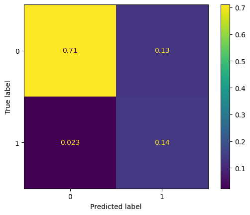

```python
#model performance evaluation on train set
from sklearn.metrics import ConfusionMatrixDisplay, confusion_matrix
import matplotlib.pyplot as plt
perf_log_reg_train_set = model_performance(log_reg_01, X_train, y_train)
print(f'''Model Performance on training set
{perf_log_reg_train_set}''')
cm=confusion_matrix(y_train, log_reg_01.predict(X_train), normalize='all')
disp = ConfusionMatrixDisplay(confusion_matrix=cm)
disp.plot()
plt.show()
```

The recall on the train set is fairly good of 85% and the FN in the confusion matrix shows 2.3% only which reflects a very good performance, yet the precision is low but the accuracy is good.

```
Model Performance on validation set
   Accuracy    Recall  Precision        F1
0  0.846761  0.832924   0.514416  0.636023
```

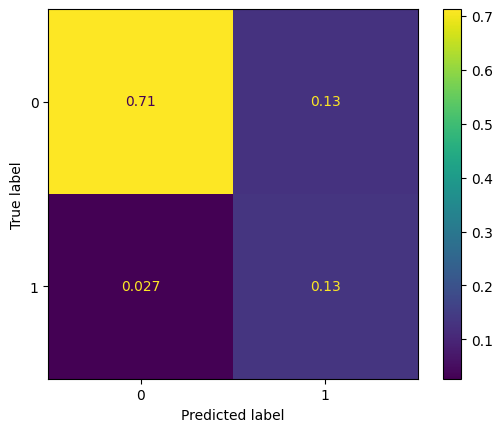

```python
from sklearn.metrics import ConfusionMatrixDisplay, confusion_matrix
import matplotlib.pyplot as plt

# Evaluate model performance on the validation set
perf_log_reg_val_set = model_performance(log_reg_01, X_val, y_val)
print(f'''Model Performance on validation set
{perf_log_reg_val_set}''')

# Step 1: Generate confusion matrix using validation data
cm = confusion_matrix(y_val, log_reg_01.predict(X_val), normalize='all')

# Step 2: Display the confusion matrix
disp = ConfusionMatrixDisplay(confusion_matrix=cm)
disp.plot()

# Show the plot
plt.show()
```

The recall on the validation set is very close the the recall on the training set which reflects a regularized model

**Decision Tree**

```python
#creating the decission tree classifier by limiting the max_depth to 5 to reduce the model overfitting
model_2 = DecisionTreeClassifier(random_state=1, max_depth=5)
dTree_1 = model_2.fit(X_train, y_train)
```

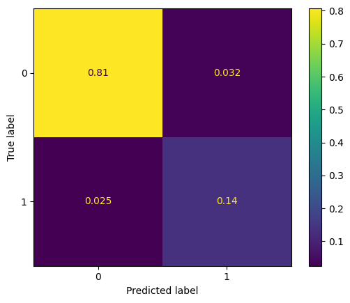

```python
from sklearn.metrics import ConfusionMatrixDisplay, confusion_matrix
import matplotlib.pyplot as plt

# Assuming dTree_1 is your trained decision tree model, and X_train, y_train are your training data

# Step 1: Generate predictions from the model
y_pred_train = dTree_1.predict(X_train)

# Step 2: Compute the confusion matrix
cm = confusion_matrix(y_train, y_pred_train, normalize='all')  # Pass y_train and y_pred_train

# Step 3: Use ConfusionMatrixDisplay to visualize the confusion matrix
disp = ConfusionMatrixDisplay(confusion_matrix=cm)
disp.plot()

# Show the plot
plt.show()
```

```
Model Performance on training set
   Accuracy    Recall  Precision        F1
0  0.942462  0.842623   0.807541  0.824709
Model Performance on training set
   Accuracy    Recall  Precision        F1
0   0.84819  0.854918   0.516592  0.644026
```

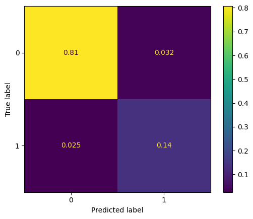

```python
from sklearn.metrics import ConfusionMatrixDisplay, confusion_matrix
import matplotlib.pyplot as plt

# Model Performance Evaluation on Training Set for Decision Tree
perf_dTree_train_set = model_performance(dTree_1, X_train, y_train)
print(f'''Model Performance on training set
{perf_dTree_train_set}''')

# Model Performance Evaluation on Training Set for Logistic Regression
perf_log_reg_train_set = model_performance(log_reg_01, X_train, y_train)
print(f'''Model Performance on training set
{perf_log_reg_train_set}''')

# Step 1: Generate predictions using the decision tree model on the training data
y_pred_train_dTree = dTree_1.predict(X_train)

# Step 2: Compute the confusion matrix using the actual labels (y_train) and predicted labels (y_pred_train_dTree)
cm = confusion_matrix(y_train, y_pred_train_dTree, normalize='all')

# Step 3: Use ConfusionMatrixDisplay to display the confusion matrix
disp = ConfusionMatrixDisplay(confusion_matrix=cm)
disp.plot()

# Show the plot
plt.show()
```

The recall on the train set is fairly good of 84% (slightly less than the logistic regression model) and the FN in the confusion matrix shows 2.5% only which reflects a very good performance. The precision and Accuracy are higher than of the logistic regression model

```
Model Performance on validation set
   Accuracy    Recall  Precision        F1
0  0.922591  0.776413   0.750594  0.763285
```

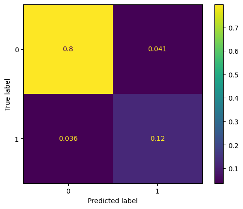

```python
from sklearn.metrics import ConfusionMatrixDisplay, confusion_matrix
import matplotlib.pyplot as plt

# Model Performance Evaluation on Validation Set for Decision Tree
perf_dTree_val_set = model_performance(dTree_1, X_val, y_val)
print(f'''Model Performance on validation set
{perf_dTree_val_set}''')

# Step 1: Generate the confusion matrix for the validation set
cm = confusion_matrix(y_val, dTree_1.predict(X_val), normalize='all')

# Step 2: Display the confusion matrix using ConfusionMatrixDisplay
disp = ConfusionMatrixDisplay(confusion_matrix=cm)
disp.plot()

# Show the plot
plt.show()
```

The model performance on the validation set is worse than on the train set showing a slight overfit in the model compared to the regularized logistic regression model.

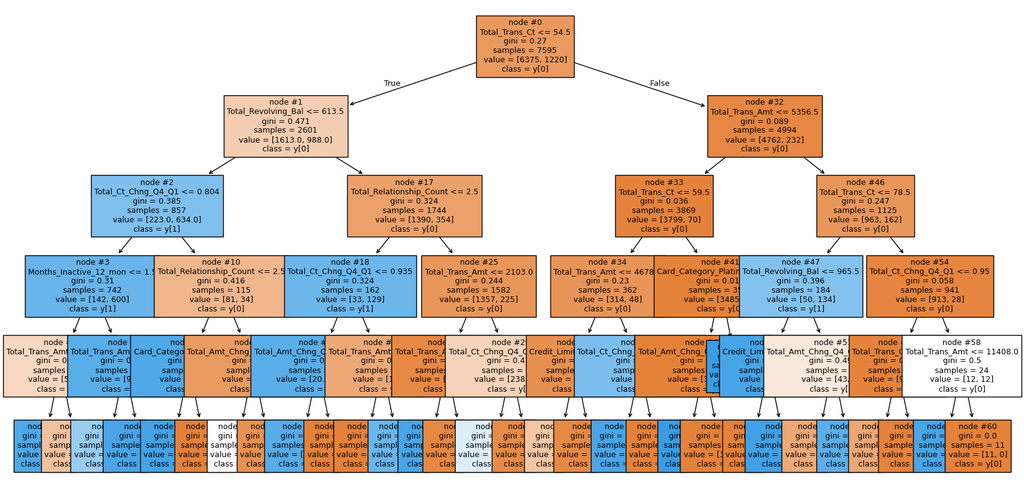

```python
#As decision trees are useful for data exploration, let us visualize the tree and explore the variables split applied
feature_names = list(X_train.columns)
plt.figure(figsize=(20,10))
tree.plot_tree(dTree_1, feature_names = feature_names, filled=True, fontsize=9,node_ids=True, class_names=True)
plt.show()
```

The decision tree first split is at the variable Total_Trans_Ct and the second split is created at the Total_Revolving_Bal and the Total_Trans_Amt , then followed by the Total_Relationship_Ct and Total_Ct_Chng_Q1_Q4 wich were all identified as strong predictors in the EDA.

**Adaboost Classifier**

```python
from sklearn.ensemble import AdaBoostClassifier

# Assuming model_1 is your base estimator (e.g., decision tree)
model_3 = AdaBoostClassifier(estimator=model_1, random_state=1)

# Fitting AdaBoost model
adaboost_1 = model_3.fit(X_train, y_train)
```

```
Model Performance on training set
   Accuracy    Recall  Precision        F1
0   0.84108  0.848361    0.50316  0.631675
```

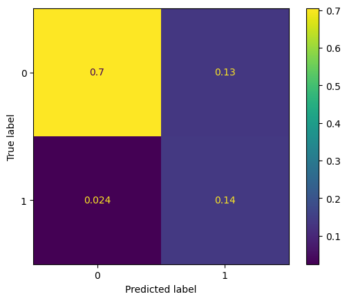

```python
#model performance evaluation on train set
from sklearn.metrics import ConfusionMatrixDisplay, confusion_matrix
import matplotlib.pyplot as plt

# Assuming `model_performance` is your custom function to evaluate model performance
perf_adaboost_train_set = model_performance(adaboost_1, X_train, y_train)
print(f'''Model Performance on training set
{perf_adaboost_train_set}''')

# Step 1: Generate confusion matrix
cm = confusion_matrix(y_train, adaboost_1.predict(X_train), normalize='all')

# Step 2: Display the confusion matrix using ConfusionMatrixDisplay
disp = ConfusionMatrixDisplay(confusion_matrix=cm)
disp.plot()

# Show the plot
plt.show()
```

The model performance is very close to the logistic regression model yet with a slightly lower recall score and slightly higher FN ratio. Let us explore the performance on the validation set.

```
Model Performance on validation set
   Accuracy    Recall  Precision        F1
0  0.838073  0.820639   0.497765  0.619666
```

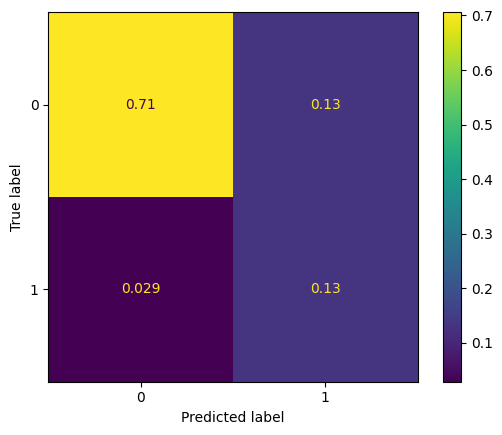

```python
#model performance evaluation on val set
from sklearn.metrics import ConfusionMatrixDisplay, confusion_matrix
import matplotlib.pyplot as plt

# Model Performance Evaluation on Validation Set for AdaBoost
perf_adaboost_val_set = model_performance(adaboost_1, X_val, y_val)
print(f'''Model Performance on validation set
{perf_adaboost_val_set}''')

# Step 1: Generate the confusion matrix for the validation set
cm = confusion_matrix(y_val, adaboost_1.predict(X_val), normalize='all')

# Step 2: Display the confusion matrix using ConfusionMatrixDisplay
disp = ConfusionMatrixDisplay(confusion_matrix=cm)
disp.plot()

# Show the plot
plt.show()
```

A very good performance is observed on the validation set with no overfitting which means the model is generalized and robust. The performance of the logistic regression model still is better, yet this model presents the second best performing model thus far.

**Gredient Boosting Classifier**

```python
#creating a Gradient boosting classifier model using the Logistic regression model_1 as its init parameter
model_4 = GradientBoostingClassifier(init = model_1, random_state=1)
gboost_1 = model_4.fit(X_train, y_train)
```

```
Model Performance on training set
   Accuracy    Recall  Precision       F1
0  0.976827  0.896721   0.956294  0.92555
```

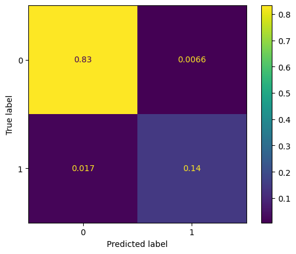

```python
#model performance evaluation on train set
from sklearn.metrics import ConfusionMatrixDisplay, confusion_matrix
import matplotlib.pyplot as plt

# Model Performance Evaluation on Training Set for Gradient Boosting
perf_gboost_train_set = model_performance(gboost_1, X_train, y_train)
print(f'''Model Performance on training set
{perf_gboost_train_set}''')

# Step 1: Generate the confusion matrix for the training set
cm = confusion_matrix(y_train, gboost_1.predict(X_train), normalize='all')

# Step 2: Display the confusion matrix using ConfusionMatrixDisplay
disp = ConfusionMatrixDisplay(confusion_matrix=cm)
disp.plot()

# Show the plot
plt.show()
```

The model performance is very good, the recall is higher than all recalls derived from adaboost and logistic regression. The FN ratio is also lower, it is yet to confirm if this model is genearlized or not.

```
Model Performance on validation set
   Accuracy   Recall  Precision        F1
0  0.968009  0.85258   0.942935  0.895484
```

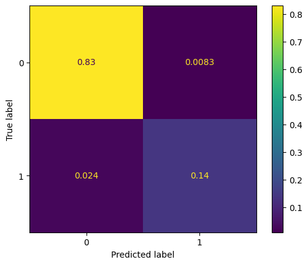

```python
#model performance evaluation on val set
from sklearn.metrics import ConfusionMatrixDisplay, confusion_matrix
import matplotlib.pyplot as plt

# Model Performance Evaluation on Validation Set for Gradient Boosting
perf_gboost_val_set = model_performance(gboost_1, X_val, y_val)
print(f'''Model Performance on validation set
{perf_gboost_val_set}''')

# Step 1: Generate the confusion matrix for the validation set
cm = confusion_matrix(y_val, gboost_1.predict(X_val), normalize='all')

# Step 2: Display the confusion matrix using ConfusionMatrixDisplay
disp = ConfusionMatrixDisplay(confusion_matrix=cm)
disp.plot()

# Show the plot
plt.show()
```

The model performance on the validation set shows that the model is not overfitting, yet it is less generalized when compared to the logistic regression and adaboost models.

**XGBoost Classifier**

```python
#creating an XGBoost classifier with eval_metric:logloss and max_depth=3 to minimize the overfitting
model_5 = XGBClassifier(random_state=1, eval_metric='logloss', max_depth=3)
xgb_1 = model_5.fit(X_train,y_train)
```

```
Model Performance on training set
   Accuracy    Recall  Precision        F1
0  0.989467  0.955738   0.978188  0.966833
```

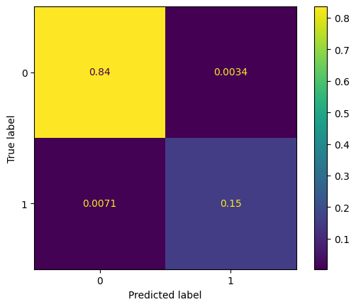

```python
#model performance evaluation on train set
from sklearn.metrics import ConfusionMatrixDisplay, confusion_matrix
import matplotlib.pyplot as plt

# Model Performance Evaluation on Training Set for XGBoost
perf_xgboost_train_set = model_performance(xgb_1, X_train, y_train)
print(f'''Model Performance on training set
{perf_xgboost_train_set}''')

# Step 1: Generate the confusion matrix for the training set
cm = confusion_matrix(y_train, xgb_1.predict(X_train), normalize='all')

# Step 2: Display the confusion matrix using ConfusionMatrixDisplay
disp = ConfusionMatrixDisplay(confusion_matrix=cm)
disp.plot()

# Show the plot
plt.show()
```

The model performance on the train set is very good with a high recall score and very small FN Ratio. The Precision and accuracy are also very high.

```
Model Performance on validation set
   Accuracy    Recall  Precision        F1
0  0.972354  0.884521   0.939948  0.911392
```

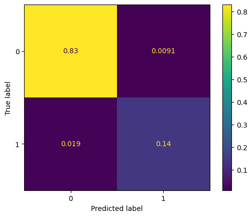

```python
#model performance evaluation on val set
from sklearn.metrics import ConfusionMatrixDisplay, confusion_matrix
import matplotlib.pyplot as plt

# Model Performance Evaluation on Validation Set for XGBoost
perf_xgboost_val_set = model_performance(xgb_1, X_val, y_val)
print(f'''Model Performance on validation set
{perf_xgboost_val_set}''')

# Step 1: Generate the confusion matrix for the validation set
cm = confusion_matrix(y_val, xgb_1.predict(X_val), normalize='all')

# Step 2: Display the confusion matrix using ConfusionMatrixDisplay
disp = ConfusionMatrixDisplay(confusion_matrix=cm)
disp.plot()

# Show the plot
plt.show()
```

The performance dropped on the validation set yet within acceptable limits of slight overfitting. The Accuracy and precision scores dropped very slightly

**Stacking Classifier**

```python
estimators = [('Logistic regression',log_reg_01), ('Decision Tree',dTree_1), ('Ada Boost',adaboost_1),
              ('XGboost',xgb_1)]

final_estimator = gboost_1

model_6= StackingClassifier(estimators=estimators,final_estimator=final_estimator)

stacking_classifier = model_6.fit(X_train,y_train)
```

```
Model Performance on training set
   Accuracy    Recall  Precision        F1
0   0.98894  0.959016   0.971761  0.965347
```

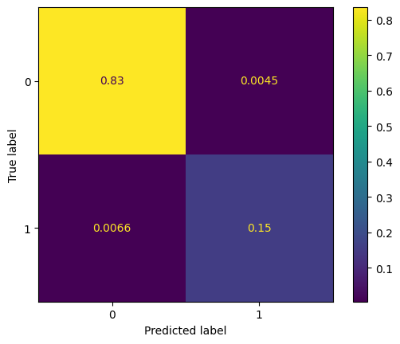

```python
#model performance evaluation on train set
from sklearn.metrics import ConfusionMatrixDisplay, confusion_matrix
import matplotlib.pyplot as plt

# Model Performance Evaluation on Training Set for Stacking Classifier
perf_stacking_train_set = model_performance(stacking_classifier, X_train, y_train)
print(f'''Model Performance on training set
{perf_stacking_train_set}''')

# Step 1: Generate the confusion matrix for the training set
cm = confusion_matrix(y_train, stacking_classifier.predict(X_train), normalize='all')

# Step 2: Display the confusion matrix using ConfusionMatrixDisplay
disp = ConfusionMatrixDisplay(confusion_matrix=cm)
disp.plot()

# Show the plot
plt.show()
```

The model perfirnance on the train set is very close to the XGBoost model with a very good recall, precision and accuracy scores.

```
Model Performance on validation set
   Accuracy    Recall  Precision     F1
0  0.969984  0.889435    0.92112  0.905
```

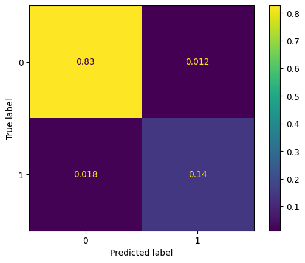

```python
#model performance evaluation on train set
from sklearn.metrics import ConfusionMatrixDisplay, confusion_matrix
import matplotlib.pyplot as plt

# Model Performance Evaluation on Validation Set for Stacking Classifier
perf_stacking_val_set = model_performance(stacking_classifier, X_val, y_val)
print(f'''Model Performance on validation set
{perf_stacking_val_set}''')

# Step 1: Generate the confusion matrix for the validation set
cm = confusion_matrix(y_val, stacking_classifier.predict(X_val), normalize='all')

# Step 2: Display the confusion matrix using ConfusionMatrixDisplay
disp = ConfusionMatrixDisplay(confusion_matrix=cm)
disp.plot()

# Show the plot
plt.show()
```

**Summary:**

The Bagging and Random Forest algorithms were trialed yet they showed a very high overfitting models. Hence, they were not included in the notebook and the six algorthims chosen for this classification problem are:

- Model 1: logistic Regression
- Model 2: Decision Tree
- Model 3: AdaBoost
- Model 4: Gradient Boost
- Model 5: XGBoost
- Model 6: Stacking

Let us sum up the model performances:

```python
models = ['logistic Regression', 'Decision Tree','AdaBoost','Gradient Boost','XGBoost','Stacking']

models_train_perf = pd.concat([perf_log_reg_train_set,
perf_dTree_train_set,
perf_adaboost_train_set,
perf_gboost_train_set,
perf_xgboost_train_set,
perf_stacking_train_set],axis=0)

models_train_perf.set_index([pd.Index(models)], inplace=True)

models_val_perf = pd.concat([perf_log_reg_val_set,
perf_dTree_val_set,
perf_adaboost_val_set,
perf_gboost_val_set,
perf_xgboost_val_set,
perf_stacking_val_set],axis=0)

models_val_perf.set_index([pd.Index(models)], inplace=True)

print("Training performance VS Validation performance comparison:")

all_models = pd.concat([models_train_perf,models_val_perf],axis=1 )
all_models
```

```
Training performance VS Validation performance comparison:
```

|  | Accuracy | Recall | Precision | F1 | Accuracy | Recall | Precision | F1 |
| --- | --- | --- | --- | --- | --- | --- | --- | --- |
| logistic Regression | 0.848190 | 0.854918 | 0.516592 | 0.644026 | 0.846761 | 0.832924 | 0.514416 | 0.636023 |
| Decision Tree | 0.942462 | 0.842623 | 0.807541 | 0.824709 | 0.922591 | 0.776413 | 0.750594 | 0.763285 |
| AdaBoost | 0.841080 | 0.848361 | 0.503160 | 0.631675 | 0.838073 | 0.820639 | 0.497765 | 0.619666 |
| Gradient Boost | 0.976827 | 0.896721 | 0.956294 | 0.925550 | 0.968009 | 0.852580 | 0.942935 | 0.895484 |
| XGBoost | 0.989467 | 0.955738 | 0.978188 | 0.966833 | 0.972354 | 0.884521 | 0.939948 | 0.911392 |
| Stacking | 0.988940 | 0.959016 | 0.971761 | 0.965347 | 0.969984 | 0.889435 | 0.921120 | 0.905000 |

Training performance VS Validation performance comparison:

The top performing models are the XGBoost, Stacking and Gradient Boost. Yet the models showing the least overfit are the logistic regression and the decision Adaboost.

**Model building - Oversampled data**

- Build 6 models using oversampled data (from logistic regression, decision trees, bagging and boosting methods) - You can choose not to build XGBoost if you are facing issues with the installation

**Oversampling train data using SMOTE**

```python
#the SMOTE alogrithm is applied with a strategy of 0.5
sm = SMOTE(sampling_strategy=0.5, k_neighbors=5, random_state=1)
X_train_over, y_train_over = sm.fit_resample(X_train, y_train)
```

```python
print(f'''Classes ratio Before Oversampling:
{y_train.value_counts()}''')

print(f'''Classes ratio After Oversampling:
{y_train_over.value_counts()}''')
```

```
Classes ratio Before Oversampling:
Attrition_Flag
0    6375
1    1220
Name: count, dtype: int64
Classes ratio After Oversampling:
Attrition_Flag
0    6375
1    3187
Name: count, dtype: int64
```

**Training the models using the over sampled train data**  
**Logistic Regression**

```python
#displaing the ratio of classes in the target variable to set the class_weight in the alogorithm
y_train_over.value_counts(normalize=True)
```

| Attrition_Flag | proportion |
| --- | --- |
| 0 | 0.666702 |
| 1 | 0.333298 |

**dtype:** float64

```python
#creating a logistic regression model using 'newton-cg' solver for its better performance on large data sets
#Also, class_weight is applied to handle the imbalance in the target variable
model_7 = LogisticRegression(random_state=1, class_weight = {0:0.333298 , 1:0.333298}, solver = 'newton-cg')
log_reg_02 = model_7.fit(X_train_over, y_train_over)
```

```
Model Performance on training set
   Accuracy    Recall  Precision        F1
0  0.897929  0.817383   0.868623  0.842224
```

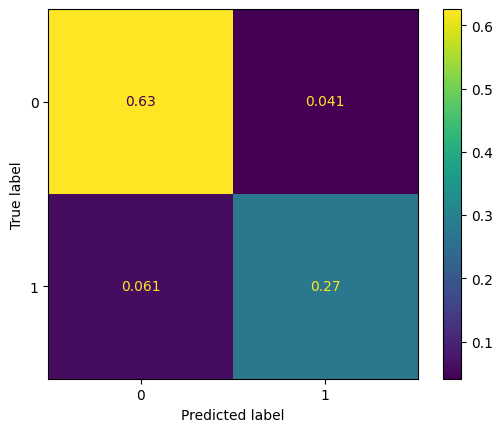

```python
#model performance evaluation on train set
from sklearn.metrics import ConfusionMatrixDisplay, confusion_matrix
import matplotlib.pyplot as plt

# Model Performance Evaluation on Training Set for Logistic Regression (with oversampling)
perf_log_reg_train_set_over = model_performance(log_reg_02, X_train_over, y_train_over)
print(f'''Model Performance on training set
{perf_log_reg_train_set_over}''')

# Step 1: Generate the confusion matrix for the oversampled training set
cm = confusion_matrix(y_train_over, log_reg_02.predict(X_train_over), normalize='all')

# Step 2: Display the confusion matrix using ConfusionMatrixDisplay
disp = ConfusionMatrixDisplay(confusion_matrix=cm)
disp.plot()

# Show the plot
plt.show()
```

```
Model Performance on validation set
   Accuracy    Recall  Precision        F1
0   0.89139  0.648649   0.666667  0.657534
```

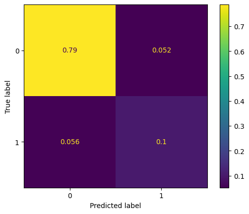

```python
#model performance evaluation on validarion set
from sklearn.metrics import ConfusionMatrixDisplay, confusion_matrix
import matplotlib.pyplot as plt

# Model Performance Evaluation on Validation Set for Logistic Regression
perf_log_reg_val_set_over = model_performance(log_reg_02, X_val, y_val)
print(f'''Model Performance on validation set
{perf_log_reg_val_set_over}''')

# Step 1: Generate the confusion matrix for the validation set
cm = confusion_matrix(y_val, log_reg_02.predict(X_val), normalize='all')

# Step 2: Display the confusion matrix using ConfusionMatrixDisplay
disp = ConfusionMatrixDisplay(confusion_matrix=cm)
disp.plot()

# Show the plot
plt.show()
```

The recall on the validation set dropped significantly which reflects an overfit model.

**Decision Tree**

```python
#creating the decission tree classifier by limiting the max_depth to 5 to reduce the model overfitting
model_8 = DecisionTreeClassifier(random_state=1, max_depth=5)
dTree_2 = model_8.fit(X_train_over, y_train_over)
```

```
Model Performance on training set
   Accuracy    Recall  Precision        F1
0  0.935474  0.890179   0.913982  0.901923
```

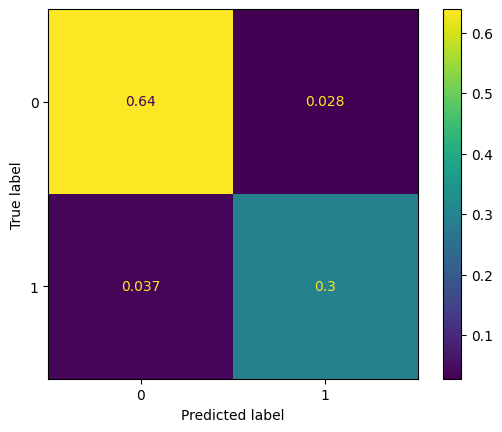

```python
#model performance evaluation on train set
from sklearn.metrics import ConfusionMatrixDisplay, confusion_matrix
import matplotlib.pyplot as plt

# Model Performance Evaluation on Training Set for Decision Tree (with oversampling)
perf_dTree_train_set_over = model_performance(dTree_2, X_train_over, y_train_over)
print(f'''Model Performance on training set
{perf_dTree_train_set_over}''')

# Step 1: Generate the confusion matrix for the oversampled training set
cm = confusion_matrix(y_train_over, dTree_2.predict(X_train_over), normalize='all')

# Step 2: Display the confusion matrix using ConfusionMatrixDisplay
disp = ConfusionMatrixDisplay(confusion_matrix=cm)
disp.plot()

# Show the plot
plt.show()
```

The recall on the train set has increased from 84% on the non-sampled data to 89% for the over sampled data. The performance is also better than the logistic regression model performance.

```
Model Performance on validation set
   Accuracy    Recall  Precision        F1
0  0.922591  0.793612   0.742529  0.767221
```

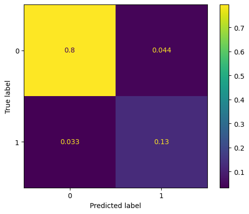

```python
#model performance evaluation on Validation set
from sklearn.metrics import ConfusionMatrixDisplay, confusion_matrix
import matplotlib.pyplot as plt

# Model Performance Evaluation on Validation Set for Decision Tree
perf_dTree_val_set_over = model_performance(dTree_2, X_val, y_val)
print(f'''Model Performance on validation set
{perf_dTree_val_set_over}''')

# Step 1: Generate the confusion matrix for the validation set
cm = confusion_matrix(y_val, dTree_2.predict(X_val), normalize='all')

# Step 2: Display the confusion matrix using ConfusionMatrixDisplay
disp = ConfusionMatrixDisplay(confusion_matrix=cm)
disp.plot()

# Show the plot
plt.show()
```

The model performance on the validation set is yet slightly better than the model with the non-sampled data, yet it relfects more overfitting.

**Adaboost Classifier**

```python
#an adaboost classifier is creaited using the base estimatore as the logistic regression model created in model_1
#this base estimator is preferred over the default decision tree as it yielded a well performing generalized model
from sklearn.ensemble import AdaBoostClassifier

# Assuming model_1 is your base estimator (e.g., a decision tree)
model_9 = AdaBoostClassifier(estimator=model_1, random_state=1)

# Fit AdaBoost model on the oversampled training data
adaboost_2 = model_9.fit(X_train_over, y_train_over)
```

```
Model Performance on training set
   Accuracy    Recall  Precision        F1
0  0.808095  0.948855   0.643952  0.767221
```

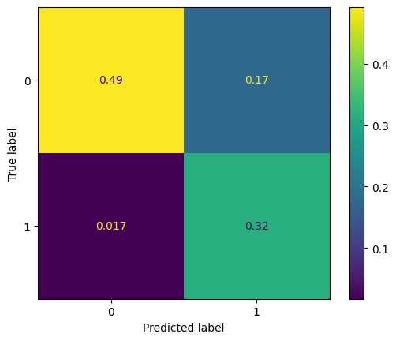

```python
#model performance evaluation on train set
from sklearn.metrics import ConfusionMatrixDisplay, confusion_matrix
import matplotlib.pyplot as plt

# Model Performance Evaluation on Oversampled Training Set for AdaBoost
perf_adaboost_train_set_over = model_performance(adaboost_2, X_train_over, y_train_over)
print(f'''Model Performance on training set
{perf_adaboost_train_set_over}''')

# Step 1: Generate the confusion matrix for the oversampled training set
cm = confusion_matrix(y_train_over, adaboost_2.predict(X_train_over), normalize='all')

# Step 2: Display the confusion matrix using ConfusionMatrixDisplay
disp = ConfusionMatrixDisplay(confusion_matrix=cm)
disp.plot()

# Show the plot
plt.show()
```

The model performance is better than logistic regression model and decision tree and also better than the Adaboost model on the non-sampled data.

```
Model Performance on validation set
   Accuracy    Recall  Precision       F1
0  0.774092  0.899263   0.408027  0.56135
```

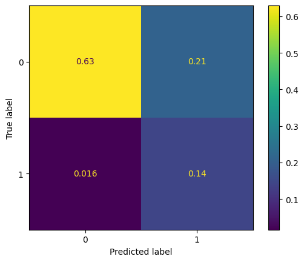

```python
#model performance evaluation on val set
from sklearn.metrics import ConfusionMatrixDisplay, confusion_matrix
import matplotlib.pyplot as plt

# Model Performance Evaluation on Validation Set for AdaBoost
perf_adaboost_val_set_over = model_performance(adaboost_2, X_val, y_val)
print(f'''Model Performance on validation set
{perf_adaboost_val_set_over}''')

# Step 1: Generate the confusion matrix for the validation set
cm = confusion_matrix(y_val, adaboost_2.predict(X_val), normalize='all')

# Step 2: Display the confusion matrix using ConfusionMatrixDisplay
disp = ConfusionMatrixDisplay(confusion_matrix=cm)
disp.plot()

# Show the plot
plt.show()
```

**Gredient Boosting Classifier**

```python
#creating a Gradient boosting classifier model using the Logistic regression model_1 as its init parameter
model_10 = GradientBoostingClassifier(init = model_1, random_state=1)
gboost_2 = model_10.fit(X_train_over, y_train_over)
```

```
Model Performance on training set
   Accuracy    Recall  Precision        F1
0  0.978456  0.960778   0.974228  0.967457
```

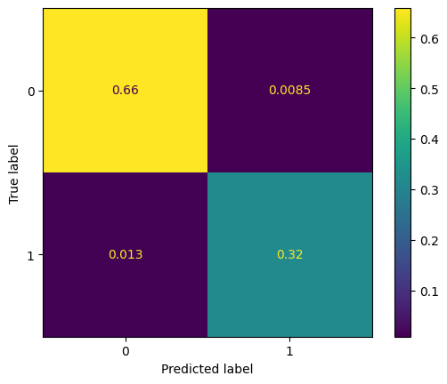

```python
#model performance evaluation on train set
from sklearn.metrics import ConfusionMatrixDisplay, confusion_matrix
import matplotlib.pyplot as plt

# Model Performance Evaluation on Oversampled Training Set for Gradient Boosting
perf_gboost_train_set_over = model_performance(gboost_2, X_train_over, y_train_over)
print(f'''Model Performance on training set
{perf_gboost_train_set_over}''')

# Step 1: Generate the confusion matrix for the oversampled training set
cm = confusion_matrix(y_train_over, gboost_2.predict(X_train_over), normalize='all')

# Step 2: Display the confusion matrix using ConfusionMatrixDisplay
disp = ConfusionMatrixDisplay(confusion_matrix=cm)
disp.plot()

# Show the plot
plt.show()
```

The model performance is very good, the recall is higher than all recalls derived from adaboost and logistic regression and Decision tree. The FN ratio is also lower, yet its performance is very close to the oversampled trained model

```
Model Performance on validation set
   Accuracy    Recall  Precision        F1
0  0.963665  0.845209   0.922252  0.882051
```

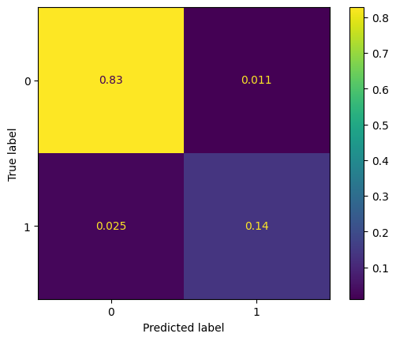

```python
from sklearn.metrics import ConfusionMatrixDisplay, confusion_matrix
import matplotlib.pyplot as plt

# Model Performance Evaluation on Validation Set for Gradient Boosting
perf_gboost_val_set_un = model_performance(gboost_2, X_val, y_val)
print(f'''Model Performance on validation set
{perf_gboost_val_set_un}''')

# Step 1: Generate the confusion matrix for the validation set
cm = confusion_matrix(y_val, gboost_2.predict(X_val), normalize='all')

# Step 2: Display the confusion matrix using ConfusionMatrixDisplay
disp = ConfusionMatrixDisplay(confusion_matrix=cm)
disp.plot()

# Show the plot
plt.show()
```

**XGBoost Classifier**

```python
#creating an XGBoost classifier with eval_metric:logloss and max_depth=3 to minimize the overfitting
model_11 = XGBClassifier(random_state=1, eval_metric='logloss', max_depth=3)
xgb_2 = model_11.fit(X_train_over,y_train_over)
```

```
Model Performance on training set
   Accuracy    Recall  Precision       F1
0  0.990274  0.982742   0.988013  0.98537
```

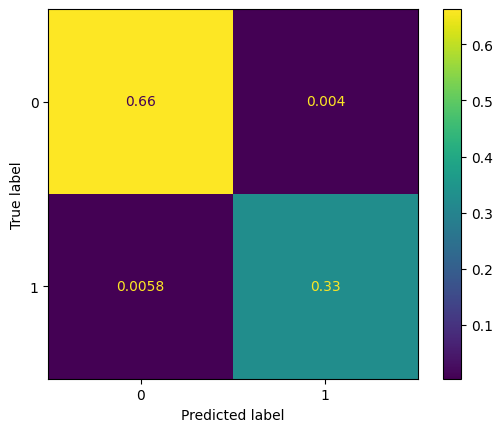

```python
from sklearn.metrics import ConfusionMatrixDisplay, confusion_matrix
import matplotlib.pyplot as plt

# Model Performance Evaluation on Oversampled Training Set for XGBoost
perf_xgboost_train_set_over = model_performance(xgb_2, X_train_over, y_train_over)
print(f'''Model Performance on training set
{perf_xgboost_train_set_over}''')

# Step 1: Generate the confusion matrix for the oversampled training set
cm = confusion_matrix(y_train_over, xgb_2.predict(X_train_over), normalize='all')

# Step 2: Display the confusion matrix using ConfusionMatrixDisplay
disp = ConfusionMatrixDisplay(confusion_matrix=cm)
disp.plot()

# Show the plot
plt.show()
```

The model performance on the train set is very good and very close to the recall observed on the GBoost model. It also shows a much smaller FN Ratio. The Precision and accuracy are also very high.

```
Model Performance on validation set
   Accuracy    Recall  Precision        F1
0  0.971959  0.894349   0.928571  0.911139
```

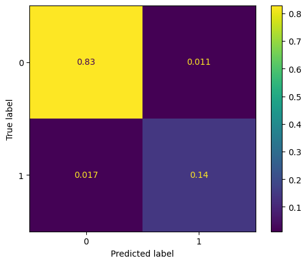

```python
from sklearn.metrics import ConfusionMatrixDisplay, confusion_matrix
import matplotlib.pyplot as plt

# Model Performance Evaluation on Validation Set for XGBoost
perf_xgboost_val_set_over = model_performance(xgb_2, X_val, y_val)
print(f'''Model Performance on validation set
{perf_xgboost_val_set_over}''')

# Step 1: Generate the confusion matrix for the validation set
cm = confusion_matrix(y_val, xgb_2.predict(X_val), normalize='all')

# Step 2: Display the confusion matrix using ConfusionMatrixDisplay
disp = ConfusionMatrixDisplay(confusion_matrix=cm)
disp.plot()

# Show the plot
plt.show()
```

**Stacking Classifier**

```python
estimators = [('Logistic regression',log_reg_02), ('Decision Tree',dTree_2), ('Ada Boost',adaboost_2),
              ('Gboost',xgb_2)]
final_estimator = gboost_2
model_18= StackingClassifier(estimators=estimators,final_estimator=final_estimator)
stacking_classifier_3 = model_18.fit(X_train,y_train)
```

```
Model Performance on training set
   Accuracy    Recall  Precision        F1
0  0.977306  0.942579   0.988808  0.965141
```

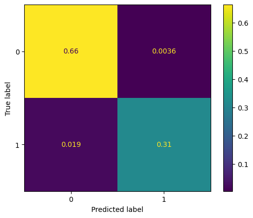

```python
from sklearn.metrics import ConfusionMatrixDisplay, confusion_matrix
import matplotlib.pyplot as plt

# Model Performance Evaluation on Oversampled Training Set for Stacking Classifier
perf_stacking_train_set_over = model_performance(stacking_classifier_3, X_train_over, y_train_over)
print(f'''Model Performance on training set
{perf_stacking_train_set_over}''')

# Step 1: Generate the confusion matrix for the oversampled training set
cm = confusion_matrix(y_train_over, stacking_classifier_3.predict(X_train_over), normalize='all')

# Step 2: Display the confusion matrix using ConfusionMatrixDisplay
disp = ConfusionMatrixDisplay(confusion_matrix=cm)
disp.plot()

# Show the plot
plt.show()
```

The model performance on the train set is very close to the Adaboost model which is slightly lower than the recall observed with XGBoost and GBoost. It is also slightly less than the performance observed with the non-sampled data.

```
Model Performance on validation set
   Accuracy    Recall  Precision    F1
0  0.971564  0.894349   0.926209  0.91
```

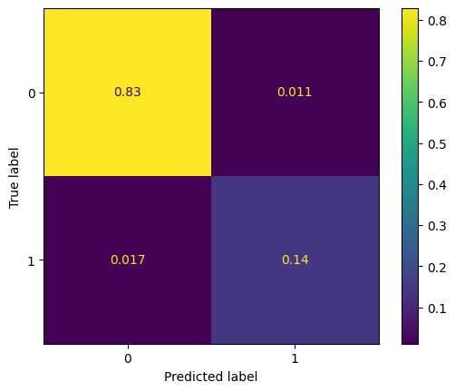

```python
from sklearn.metrics import ConfusionMatrixDisplay, confusion_matrix
import matplotlib.pyplot as plt

# Model Performance Evaluation on Validation Set for Stacking Classifier
perf_stacking_val_set_over = model_performance(stacking_classifier_3, X_val, y_val)
print(f'''Model Performance on validation set
{perf_stacking_val_set_over}''')

# Step 1: Generate the confusion matrix for the validation set
cm = confusion_matrix(y_val, stacking_classifier_3.predict(X_val), normalize='all')

# Step 2: Display the confusion matrix using ConfusionMatrixDisplay
disp = ConfusionMatrixDisplay(confusion_matrix=cm)
disp.plot()

# Show the plot
plt.show()
```

```python
models_2 = ['Logistic Regression', 'Decision Tree', 'AdaBoost', 'Gradient Boost', 'XGBoost', 'Stacking']

# Concatenating training performance
perf_gboost_val_set_over = model_performance(gboost_2, X_val, y_val)
models_train_perf_over = pd.concat([perf_log_reg_train_set_over,
                                    perf_dTree_train_set_over,
                                    perf_adaboost_train_set_over,
                                    perf_gboost_train_set_over,
                                    perf_xgboost_train_set_over,
                                    perf_stacking_train_set_over], axis=0)

models_train_perf_over.set_index([pd.Index(models_2)], inplace=True)

# Concatenating validation performance
models_val_perf_over = pd.concat([perf_log_reg_val_set_over,
                                  perf_dTree_val_set_over,
                                  perf_adaboost_val_set_over,
                                  perf_gboost_val_set_over,
                                  perf_xgboost_val_set_over,
                                  perf_stacking_val_set_over], axis=0)

models_val_perf_over.set_index([pd.Index(models_2)], inplace=True)

# Combining both training and validation performances for comparison
all_models_over = pd.concat([models_train_perf_over.add_suffix('_Train'),
                             models_val_perf_over.add_suffix('_Val')], axis=1)

print("Training performance VS Validation performance comparison with Over-Sampled Train Data:")
all_models_over
```

```
Training performance VS Validation performance comparison with Over-Sampled Train Data:
```

|  | Accuracy_Train | Recall_Train | Precision_Train | F1_Train | Accuracy_Val | Recall_Val | Precision_Val | F1_Val |
| --- | --- | --- | --- | --- | --- | --- | --- | --- |
| Logistic Regression | 0.897929 | 0.817383 | 0.868623 | 0.842224 | 0.891390 | 0.648649 | 0.666667 | 0.657534 |
| Decision Tree | 0.935474 | 0.890179 | 0.913982 | 0.901923 | 0.922591 | 0.793612 | 0.742529 | 0.767221 |
| AdaBoost | 0.808095 | 0.948855 | 0.643952 | 0.767221 | 0.774092 | 0.899263 | 0.408027 | 0.561350 |
| Gradient Boost | 0.978456 | 0.960778 | 0.974228 | 0.967457 | 0.963665 | 0.845209 | 0.922252 | 0.882051 |
| XGBoost | 0.990274 | 0.982742 | 0.988013 | 0.985370 | 0.971959 | 0.894349 | 0.928571 | 0.911139 |
| Stacking | 0.977306 | 0.942579 | 0.988808 | 0.965141 | 0.971564 | 0.894349 | 0.926209 | 0.910000 |

**Hyperparameter tuning using random search**

```python
from imblearn.under_sampling import RandomUnderSampler
perf_adaboost_val_set_un = model_performance(adaboost_2, X_val, y_val)
# Assuming xgb_2 is your XGBoost model trained on the undersampled data
perf_xgboost_val_set_un = model_performance(xgb_2, X_val, y_val)
# Assuming gboost_2 is your Gradient Boosting model trained on the undersampled data
perf_gboost_val_set_un = model_performance(gboost_2, X_val, y_val)
# Create undersampled training data
undersampler = RandomUnderSampler(random_state=1)
X_train_un, y_train_un = undersampler.fit_resample(X_train, y_train)

# Compute the AdaBoost performance on undersampled training set
perf_adaboost_train_set_un = model_performance(adaboost_2, X_train_un, y_train_un)

# Similarly, calculate performance for Gradient Boost and XGBoost if not already done
perf_gboost_train_set_un = model_performance(gboost_2, X_train_un, y_train_un)
perf_xgboost_train_set_un = model_performance(xgb_2, X_train_un, y_train_un)

# Continue with concatenating the model performance
models_to_tune = ['AdaBoost', 'Gradient Boost', 'XGBoost']

# Concatenating training performance for the models to tune
train_perf_to_tune = pd.concat([
    perf_adaboost_train_set_un,
    perf_gboost_train_set_un,
    perf_xgboost_train_set_un], axis=0)

train_perf_to_tune.set_index([pd.Index(models_to_tune)], inplace=True)

# Concatenating validation performance for the models to tune
val_perf_un = pd.concat([
    perf_adaboost_val_set_un,
    perf_gboost_val_set_un,
    perf_xgboost_val_set_un], axis=0)

val_perf_un.set_index([pd.Index(models_to_tune)], inplace=True)

# Adding suffixes for training and validation performance
to_tune_models = pd.concat([train_perf_to_tune.add_suffix('_Train'),
                            val_perf_un.add_suffix('_Val')], axis=1)

print("Training performance VS Validation performance comparison with the best 3 models to tune:")
to_tune_models
```

```
Training performance VS Validation performance comparison with the best 3 models to tune:
```

|  | Accuracy_Train | Recall_Train | Precision_Train | F1_Train | Accuracy_Val | Recall_Val | Precision_Val | F1_Val |
| --- | --- | --- | --- | --- | --- | --- | --- | --- |
| AdaBoost | 0.832377 | 0.918852 | 0.783368 | 0.845719 | 0.774092 | 0.899263 | 0.408027 | 0.561350 |
| Gradient Boost | 0.946721 | 0.905738 | 0.986607 | 0.944444 | 0.963665 | 0.845209 | 0.922252 | 0.882051 |
| XGBoost | 0.974590 | 0.956557 | 0.992347 | 0.974124 | 0.971959 | 0.894349 | 0.928571 | 0.911139 |

Training performance VS Validation performance comparison with the best 3 models to tune:

**Tuning Adaboost**

```python
from xgboost import XGBClassifier
from sklearn.ensemble import AdaBoostClassifier
from sklearn.tree import DecisionTreeClassifier
from sklearn.model_selection import RandomizedSearchCV
adaboost = AdaBoostClassifier(estimator=DecisionTreeClassifier(), random_state=1)
parameters = {
    #Let's try different max_depth for base_estimator
    "base_estimator":[DecisionTreeClassifier(max_depth=1),DecisionTreeClassifier(max_depth=2),
                      DecisionTreeClassifier(max_depth=3),DecisionTreeClassifier(max_depth=5),
                      DecisionTreeClassifier(max_depth=7)],
    "n_estimators": np.arange(10,150,10),
    "learning_rate":np.arange(0.1,2,0.1)
}
randomized_cv = RandomizedSearchCV(estimator=adaboost, param_distributions=parameters, n_iter=10, random_state=1, cv=5)
model_15 = AdaBoostClassifier(random_state=1 )
# Step 1: Train the XGBoost model on the undersampled training data
xgb_2 = XGBClassifier(random_state=1)
xgb_2.fit(X_train_un, y_train_un)

# Step 2: Evaluate the XGBoost model on the validation set
perf_xgboost_val_set_un = model_performance(xgb_2, X_val, y_val)

scorer = metrics.make_scorer(metrics.recall_score)

# Calling RandomizedSearchCV
randomized_cv = RandomizedSearchCV(
    estimator=model_15,
    param_distributions=parameters,
    n_iter=40,
    scoring=scorer,
    cv=5,
    random_state=1,
)

# Fitting parameters in RandomizedSearchCV
#randomized_cv.fit(param_distributions, scoring)

print(
   "Best parameters are {} with CV score={}:".format(
      randomized_cv.estimator, randomized_cv.param_distributions
   )
)
```

[output not shown]

```python
from sklearn.ensemble import AdaBoostClassifier
from sklearn.tree import DecisionTreeClassifier

# Create the AdaBoost model with the tuned parameters
model_15_tuned = AdaBoostClassifier(
    n_estimators=80,
    learning_rate=0.2,
    estimator=DecisionTreeClassifier(max_depth=3),  # Use 'estimator' instead of 'base_estimator'
    random_state=1
)

# Fit the tuned model on the undersampled training data
Adaboost_tuned = model_15_tuned.fit(X_train_un, y_train_un)
```

```
Model Performance on training set
   Accuracy   Recall  Precision        F1
0  0.998361  0.99918   0.997545  0.998362
```

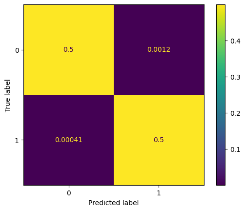

```python
from sklearn.metrics import ConfusionMatrixDisplay, confusion_matrix
import matplotlib.pyplot as plt

# Model Performance Evaluation on Training Set for Tuned AdaBoost Model
perf_ada_tuned_train_set = model_performance(Adaboost_tuned, X_train_un, y_train_un)
print(f'''Model Performance on training set
{perf_ada_tuned_train_set}''')

# Step 1: Generate the confusion matrix for the training set
cm = confusion_matrix(y_train_un, Adaboost_tuned.predict(X_train_un), normalize='all')

# Step 2: Display the confusion matrix using ConfusionMatrixDisplay
disp = ConfusionMatrixDisplay(confusion_matrix=cm)
disp.plot()

# Show the plot
plt.show()
```

```
Model Performance on validation set
   Accuracy    Recall  Precision        F1
0  0.945893  0.948403   0.768924  0.849285
```

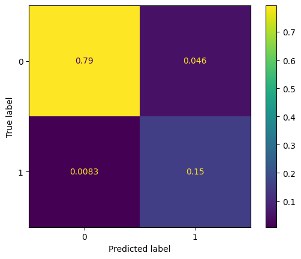

```python
#model performance evaluation on val set
from sklearn.metrics import ConfusionMatrixDisplay, confusion_matrix
import matplotlib.pyplot as plt

# Model Performance Evaluation on Validation Set for Tuned AdaBoost Model
perf_ada_tuned_val_set = model_performance(Adaboost_tuned, X_val, y_val)
print(f'''Model Performance on validation set
{perf_ada_tuned_val_set}''')

# Step 1: Generate the confusion matrix for the validation set
cm = confusion_matrix(y_val, Adaboost_tuned.predict(X_val), normalize='all')

# Step 2: Display the confusion matrix using ConfusionMatrixDisplay
disp = ConfusionMatrixDisplay(confusion_matrix=cm)
disp.plot()

# Show the plot
plt.show()
```

**Tuning Gradient Boost**

```python
model_16 = GradientBoostingClassifier(init = LogisticRegression(random_state=1, solver = 'newton-cg'), random_state=1)

# Parameter grid to pass in RandomizedSearchCV
# Grid of parameters to choose from
parameters = {
    "n_estimators": np.arange(10,150,10),
    "subsample":np.arange(0.8,0.9,0.1),
    "max_features":np.arange(0.3,1,0.1)
}


# Type of scoring used to compare parameter combinations
scorer = metrics.make_scorer(metrics.recall_score)

# Calling RandomizedSearchCV
randomized_cv = RandomizedSearchCV(
    estimator=model_16,
    param_distributions=parameters,
    n_iter=40,
    scoring=scorer,
    cv=5,
    random_state=1,
)

# Fitting parameters in RandomizedSearchCV
randomized_cv.fit(X_train_un, y_train_un)

print(
    "Best parameters are {} with CV score={}:".format(
        randomized_cv.best_params_, randomized_cv.best_score_
    )
)
```

```
Best parameters are {'subsample': 0.8, 'n_estimators': 130, 'max_features': 0.5} with CV score=0.9565573770491802:
```